# Project Business Statistics: E-news Express

### Bivariate Analysis

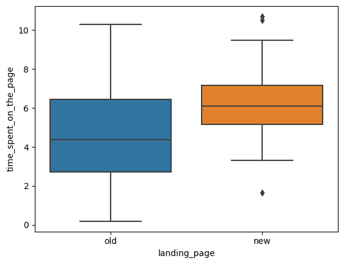

```python
# Analysis of time_spent_on_the_page vs landing_page
sns.boxplot(x='landing_page',y='time_spent_on_the_page',data=enews_df);
```

As you can see user spend more time if landing page is new compare with old landing page.

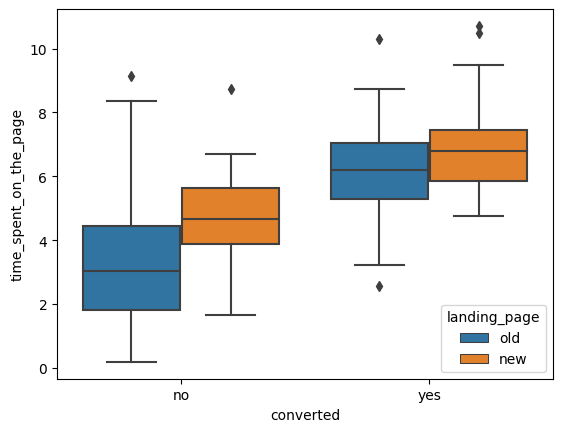

```python
# Analysis of time_spent_on_the_page vs converted and landing_page
sns.boxplot(x='converted',y='time_spent_on_the_page',data=enews_df,hue='landing_page');
```

As you can see if user spent more time on landing page then there are more chances of them to convert to subscription to the news portal. User spent more time on new page then old irrespective of they convert to subscription or not.

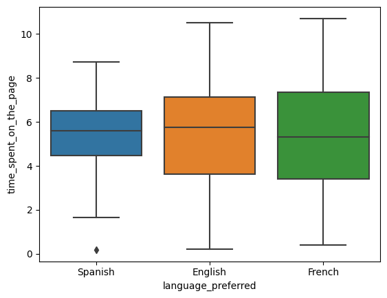

```python
# Analysis of time_spent_on_the_page vs language_prefered
sns.boxplot(x='language_preferred',y='time_spent_on_the_page',data=enews_df);
```

Most of the user with Spanish or French or English language prefered spent same average amount of time on the page.

## 1. Do the users spend more time on the new landing page than the existing landing page?

### Perform Visual Analysis

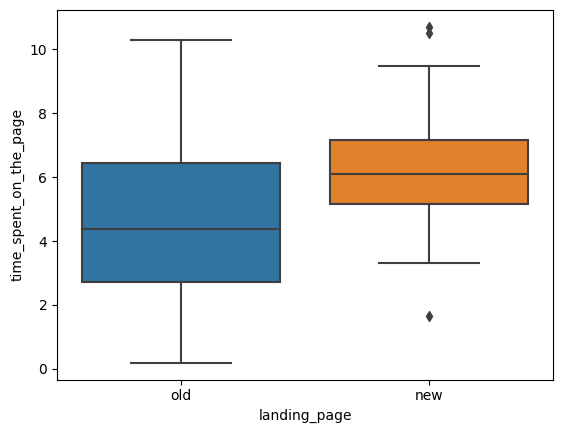

```python
# Analysis of time_spent_on_the_page vs landing_page
sns.boxplot(x='landing_page',y='time_spent_on_the_page',data=enews_df);
```

As per the box plot above Users's spent more time on new landing page compared with old landing page.

### Step 1: Define the null and alternate hypotheses

Let μ1,μ2 be the mean time spent by user on old and new landing page respectively.

We will test the null hypothesis

H0:μ1 = μ2

against the alternate hypothesis

Ha:μ1 < μ2

### Step 2: Select Appropriate test

### Let's test whether the Two Independent Sample T-test for Equality of Means assumptions are satisfied or not

- Continuous data - Yes, the usage time is measured on a continuous scale.
- Normally distributed populations - Yes, Time spent by user data are normaly distributed.
- Independent populations - As we are taking random samples for two different type of users, the two samples are from two independent populations.
- Unequal population standard deviations - As the sample standard deviations are different as calculated below, the population standard deviations may be assumed to be different
- Random sampling from the population - Yes, we are informed that the collected sample is a simple random sample.

We can use Two Independent Sample T-test for Equality of Means - Unequal Std Dev

### Step 3: Decide the significance level

As per the problem statement, we can select

# α

0.05 .

### Step 4: Collect and prepare data

```python
# find the sample means and sample standard deviations for the two samples
print('The mean time spent by user on old page is ' + str(enews_df[enews_df['landing_page'] == 'old']['time_spent_on_the_page'].mean()))
print('The mean time spent by user on new page is ' + str(enews_df[enews_df['landing_page'] == 'new']['time_spent_on_the_page'].mean()))
print('The standard deviation for the time spent by user on old page is ' + str(round(enews_df[enews_df['landing_page'] == 'old']['time_spent_on_the_page'].std(),2)))
print('The standard deviation for the time spent by user on new page is ' + str(round(enews_df[enews_df['landing_page'] == 'new']['time_spent_on_the_page'].std(),2)))
```

```
The mean time spent by user on old page is 4.532400000000001
The mean time spent by user on new page is 6.2232
The standard deviation for the time spent by user on old page is 2.58
The standard deviation for the time spent by user on new page is 1.82
```

As standard deviation is not same for both the population we can use Two Independent Sample T-test for Equality of Means - UnEqual Std Dev

### Step 5: Calculate the p-value

```python
#import the required functions
from scipy.stats import ttest_ind

# find the p-value
test_stat, p_value = ttest_ind(enews_df[enews_df['landing_page'] == 'old']['time_spent_on_the_page'], enews_df[enews_df['landing_page'] == 'new']['time_spent_on_the_page'], equal_var = False, alternative = 'less')
print('The p-value is ' + str(p_value))
```

```
The p-value is 0.0001392381225166549
```

### Step 6: Compare the p-value with $\alpha$

p- value is less then $\alpha$.

### Step 7: Draw inference

As the p-value (~0.00013) is less than the level of significance, we can reject the null hypothesis. Hence, we do have enough evidence to support the claim that user spend more time on new landing page then the old landing page.

**A similar approach can be followed to answer the other questions.**

## 2. Is the conversion rate (the proportion of users who visit the landing page and get converted) for the new page greater than the conversion rate for the old page?

**Perform Visual Analysis**

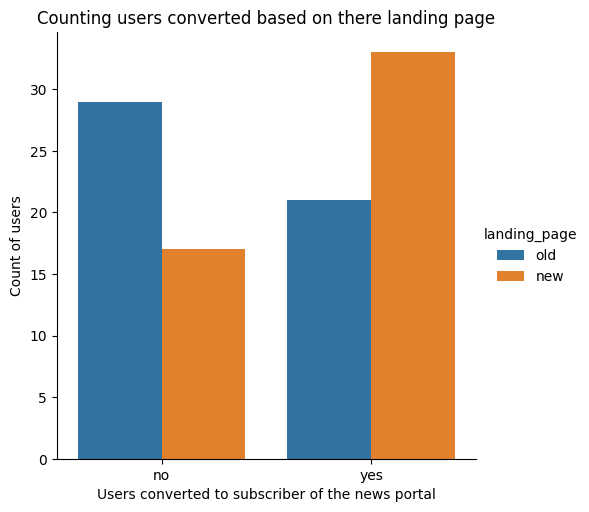

```python
# Performing visual analysis of the number of users converted based on there landing page
sns.catplot(x='converted',data=enews_df,hue='landing_page',kind='count')
plt.title('Counting users converted based on there landing page')
plt.xlabel('Users converted to subscriber of the news portal')
plt.ylabel('Count of users')
```

As you can see conversion rate is more for the new landing page compared with old landing page.

**Step 1: Define the null and alternate hypotheses**

### Let's write the null and alternative hypothesis

Let $p_1,p_2$ be the conversion rate old and new landing page respectively.

The manufacturer will test the null hypothesis

> $H_0:p_1 =p_2$

against the alternate hypothesis

> $H_a:p_1 < p_2$

**Step 2: Select Appropriate test**

Let's test whether the Two Proportion Z-test assumptions are satisfied or not.

Binomally distributed population - Yes, a users is either converted or not converted.

Random sampling from the population - Yes, we are informed that the collected sample is a simple random sample.

binomial distribution approximated to normal distribution and For binary data, CLT works slower than usual. So I will check whether np and n(1-p) are greater than or equal to 10. Here, n and p refer to the sample size and sample proportion respectively. for old landing page n = 50 p1 = 21

for new landing page n = 50 p2 = 33

> $np_1 = 50\cdot \frac{21}{50} =21 \geq 10\\ n(1-p_1) = 50 \cdot \frac{50-21}{50} =29 \geq 10 \\ np_2 = 50\cdot \frac{33}{50} =33 \geq 10\\ n(1-p_2) = 50 \cdot \frac{50-33}{50} =17 \geq 10 $

So we can pick Two Proportion Z-test.

```python
# Calculating number users who got old_landing page and still subscriber to the news portal
convert_old = enews_df[enews_df['landing_page'] == 'old']['converted'].value_counts()['yes']
print('Number users who got old_landing page and still subscriber to the news portal:',convert_old)
# calculating total number of user who got old landing page
n_totalold = enews_df[enews_df['landing_page'] == 'old'].shape[0]
print('Total number of user who got old landing page:',n_totalold)
```

```
Number users who got old_landing page and still subscriber to the news portal: 21
Total number of user who got old landing page: 50
```

```python
# Calculating number users who got new_landing page and still subscriber to the news portal
convert_new = enews_df[enews_df['landing_page'] == 'new']['converted'].value_counts()['yes']
print('Number users who got new_landing page and still subscriber to the news portal:',convert_new)
# calculating total number of user who got old landing page
n_totalnew = enews_df[enews_df['landing_page'] == 'new'].shape[0]
print('Total number of user who got new landing page:',n_totalnew)
```

```
Number users who got new_landing page and still subscriber to the news portal: 33
Total number of user who got new landing page: 50
```

**Step 3: Decide the significance level**

As per the problem statement, we can select

# α

0.05

**Step 4: Calculate the p-value**

```python
# import the required fuction
from statsmodels.stats.proportion import proportions_ztest

# set the counts old and new converted user counts
converted_count = np.array([convert_old, convert_new])

# set the sample sizes
nobs = np.array([n_totalold, n_totalnew])

# find the p-value
test_stat, p_value = proportions_ztest(converted_count, nobs,alternative = 'smaller')
print('The p-value is ' + str(p_value))
```

```
The p-value is 0.008026308204056278
```

**Step 5: Compare the p-value with $\alpha$**

p- value is less then $\alpha$.

**Step 6: Draw inference**

As the p-value (~0.008) is less than the level of significance, we can reject the null hypothesis. Hence, we do have enough evidence to support the claim that conversion rate for new landing page is more then the same for old landing page.

## 3. Is the conversion and preferred language are independent or related?

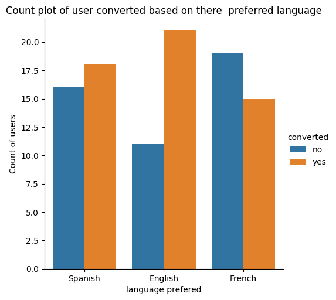

```python
# Performing visual analysis of the number of users converted based on there prefered language
sns.catplot(x='language_preferred',data=enews_df,hue='converted',kind='count')
plt.title('Count plot of user converted based on there  preferred language')
plt.xlabel('language prefered')
plt.ylabel('Count of users')
```

```python
enews_df.groupby('language_preferred')['converted'].value_counts()
```

```
language_preferred  converted
English             yes          21
                    no           11
French              no           19
                    yes          15
Spanish             yes          18
                    no           16
Name: converted, dtype: int64
```

As we can see that proportion of converted for user with 'English' language preference are little more followed by 'Spanish' and then 'French'.

**Step 1: Define the null and alternate hypotheses**

Let's write the null and alternative hypothesis

We will test the null hypothesis

> $H_0:$ conversion and language_prefered are independent.

against the alternate hypothesis

> $H_a:$ conversion and language_prefered are dependent.

**Step 2: Select Appropriate test**

### Let's test whether the assumptions for Chi-Square Test for Independence are satisfied or not

- Categorical variables - Yes
- Expected value of the number of sample observations in each level of the variable is at least 5 - Yes, the number of observations in each level is greater than 5.
- Random sampling from the population - Yes, we are informed that the collected sample is a simple random sample.

As all the assumptions are satisfied we can use Chi-Square Test for Independence.

**Step 3: Decide the significance level**

As per the problem statement, we can select α = 0.05

**Step 4: Collect and prepare data**

```python
# create the contingency table showing the distribution of the two categorical variables
contingency_table = pd.crosstab(enews_df['language_preferred'],enews_df['converted'])
contingency_table
```

| converted language_preferred | no | yes |
| --- | --- | --- |
| English | 11 | 21 |
| French | 19 | 15 |
| Spanish | 16 | 18 |

**Step 5: Calculate the p-value**

```python
from scipy.stats import chi2_contingency   # For Chi-Square test
# use chi2_contingency() to find the p-value
chi2, pval, dof, exp_freq = chi2_contingency(contingency_table)
# print the p-value
print('The p-value is', pval)
```

```
The p-value is 0.2129888748754345
```

**Step 6: Compare the p-value with $\alpha$**

p- value is greater then $\alpha$.

**Step 7: Draw inference**

As the p-value (~0.213) is greater than the level of significance, we are fail to reject the null hypothesis. Hence, We accept the null hypothesis that conversion and language_prefered are independent.

## 4. Is the time spent on the new page same for the different language users?

**Perform Visual Analysis**

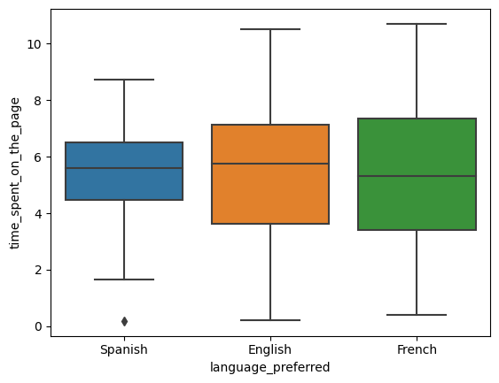

```python
# Analysis of time_spent_on_the_page vs language_prefered
sns.boxplot(x='language_preferred',y='time_spent_on_the_page',data=enews_df);
```

As you can see average time spent by most of the users with Spanish or English or French language preferred are the same.

**Step 1: Define the null and alternate hypotheses**

### Let's write the null and alternative hypothesis

Let $\mu_1, \mu_2, \mu_3$ be the means of the time spent on new landing page by user of Spanish,English and French language prefered respectively.

We will test the null hypothesis

> $H_0: \mu_1 = \mu_2 = \mu_3$

against the alternative hypothesis

> $H_a: $ At least one mean is different from the rest.

**Step 2: Select Appropriate test**

### Let's test whether the assumptions for One-way ANOVA Test are satisfied or not

- The populations are normally distributed. We did prove it with the Shapiro-Wilk’s test
- Samples are independent simple random samples
- Population variances are equal and the homogeneity of variance assumption is verified using the Levene's test as below

**Step 3: Decide the significance level**

As per the problem statement, we can select

# α

0.05

**Step 4: Collect and prepare data**

```python
# Creating dataframe for only user visiting new landing page
df_new = enews_df[enews_df['landing_page'] == 'new']
df_new.head()
```

|  | user_id | group | landing_page | time_spent_on_the_page | converted | language_preferred |
| --- | --- | --- | --- | --- | --- | --- |
| 1 | 546468 | treatment | new | 7.13 | yes | English |
| 2 | 546462 | treatment | new | 4.40 | no | Spanish |
| 4 | 546459 | treatment | new | 4.75 | yes | Spanish |
| 6 | 546448 | treatment | new | 5.25 | yes | French |
| 8 | 546461 | treatment | new | 10.71 | yes | French |

### Shapiro-Wilk’s test to check for One-Way Anova test assumption of Normality

We will test the null hypothesis

> $H_0$: Time spent on new landing page follow normal distribution

against the alternative hypothesis

> $H_a$: Time spent on new landing page do not follow normal distribution

```python
# Use the shapiro function for the scipy.stats library for this test
import scipy.stats as stats
# find the p-value
w, p_value = stats.shapiro(df_new['time_spent_on_the_page'])
print('The p-value is', p_value)
```

```
The p-value is 0.8040016293525696
```

Since p-value of the test is very large than the 5% significance level, we fail to reject the null hypothesis that the response follows the normal distribution.

### Levene’s test to check for One-Way Anova test assumption of equal variance

We will test the null hypothesis

> $H_0$: All the population variances are equal

against the alternative hypothesis

> $H_a$: At least one variance is different from the rest

```python
#Assumption : Homogeneity of Variance
#import the required function
from scipy.stats import levene
statistic, p_value = levene( df_new['time_spent_on_the_page'][df_new['language_preferred']=="Spanish"],
                                   df_new['time_spent_on_the_page'][df_new['language_preferred']=="English"],
                                   df_new['time_spent_on_the_page'][df_new['language_preferred']=="French"])
# find the p-value
print('The p-value is', p_value)
```

```
The p-value is 0.46711357711340173
```

As p value is higher then level of significance(0.05) we accept the null hypothesis and says that All the population variances are equal so we can use One-Way Anova test.

**Step 5: Calculate the p-value**

```python
#import the required function
from scipy.stats import f_oneway

# perform one-way anova test
test_stat, p_value = f_oneway(df_new.loc[df_new['language_preferred'] == 'Spanish', 'time_spent_on_the_page'],
                              df_new.loc[df_new['language_preferred'] == 'English', 'time_spent_on_the_page'],
                              df_new.loc[df_new['language_preferred'] == 'French', 'time_spent_on_the_page'],)
print('The p-value is ' + str(p_value))
```

```
The p-value is 0.43204138694325955
```

**Step 6: Compare the p-value with $\alpha$**

p- value is greater then $\alpha$.

**Step 7: Draw inference**

As the p-value (~0.432) is greater than the level of significance, we are fail to reject the null hypothesis. Hence, we do not have enough evidence to support the claim that the means of the time spent on new landing page by user of Spanish,English and French language are different. We accept the null hypothesis that means of the time spent on new landing page by user of Spanish,English and French language are same.

## Conclusion and Business Recommendations

1. From sample data, it was observed that user spend more time if landing  
   page is new compare with old landing page.
2. It was also observed that if user spent more time on landing page then there are more chances of them to convert to subscription to the news portal. User spent more time on new page then old irrespective of they convert to subscription or not.
3. Most of the users spent between 4 to 7 minutes and the time spent on the  
   page by users is normally distributed. Minimum timespent by user is 0.19 mins and maximum time spent by user is 10.71 mins with median of 5.415 mins.
4. We do have enough evidence to support the claim that user spend more time on new landing page then the old landing page.so it is recommended to use new landing page.
5. We do have enough statistical evidence to support the claim that  
   conversion rate for new landing page is more then the conversion rate for old landing page. So again it is recommended to use new landing page.
6. We do not have statistical evidence to support the claim that Converted  
   and language_prefered are dependent so Converted user subscriber  
   and language_prefered are independent so it means that users prefered language landing page might not be helping in getting that user subscribed.
7. We do not have enough statistical evidence to support the claim that the means of the time spent on new landing page by user of Spanish,English and French language are different. Mean time spent on new landing page by users of different prefered languages are same.